# Visualización de datos

Construimos nuestro dataset en base a los datos extraídos de la web de Crossfit. Para cada atleta, tenemos la siguiente información:

- Personal data
  - nombre
  - apellidos
  - pais
  - CFID
  - division
  - edad
  - altura
  - peso
  - affiliate
- Benchmark Stats
  - Weightlifting
    - Back Squat
    - Clean and Jerk
    - Snatch
    - Deadlift
  - Reps
    - Fight Gone Bad
    - Max Pullups
  - For time (seconds)
    - Fran
    - Grace
    - Helen
    - Filthy 50
    - Sprint 400m
    - Run 5k

# Scrapping

Importante destacar que antes de realizar las gráficas de los datos, debemos extraer los datos de la web de Crossfit. Para ello he utilizado la librería [BeautifulSoup](https://www.crummy.com/software/BeautifulSoup/bs4/doc/). Y he realizado un pequeño preprocesado para construir el dataset que posteriormente he utilizado para realizar este notebook.

# Carga y limpieza de datos

Como se ha realizado un proceso de scrapping es altamente probable que se hayan producido errores y/o los datos no tengan el formato adecuado para su uso. Es adecuador limpiar los datos y realizar las transformaciones o imputaciones necesarias para que la visualización sea más fácil. En este caso, el objetivo es analizar las marcas de los atletas, separar aquellas que son cargadas, con respecto a las que la puntuación se calcula en base al tiempo en acabar el entreno, y las que son por número de repeticiones. Tambien me parece adecuado, analizar las marcar con respecto al índice de masa corporal (peso y altura).

```python
# load data
import pandas as pd
import numpy as np

df = pd.read_csv('processed/data.csv')
df.head(10)
```

|  | Unnamed: 0 | id | name | country | division | gender | age | height | weight | IMC | ... | snatch | deadlift | fight_gone_bad | max_pull_ups | fran | grace | helen | filthy_50 | sprint_400m | run_5k |
| --- | --- | --- | --- | --- | --- | --- | --- | --- | --- | --- | --- | --- | --- | --- | --- | --- | --- | --- | --- | --- | --- |
| 0 | 0 | 1 | Lin Yi | -- | -- | -- | 37 | 170.18 | 73.935496 | 25.529126 | ... | 0.00000 | 0.00000 | -- | 30 | 0 | 0 | 0 | 0 | 0 | 0 |
| 1 | 1 | 10 | system test | -- | -- | -- | 122 | -- | -- | 0.000000 | ... | 0.00000 | 0.00000 | -- | -- | 0 | 0 | 0 | 0 | 0 | 0 |
| 2 | 2 | 11 | user1 test | -- | -- | -- | 122 | -- | -- | 0.000000 | ... | 0.00000 | 0.00000 | -- | -- | 0 | 0 | 0 | 0 | 0 | 0 |
| 3 | 3 | 12 | user2 test | -- | -- | -- | 122 | -- | -- | 0.000000 | ... | 0.00000 | 0.00000 | -- | -- | 0 | 0 | 0 | 0 | 0 | 0 |
| 4 | 4 | 82 | Adam Reed | -- | -- | -- | 36 | 185.42 | 88.904032 | 25.858796 | ... | 0.00000 | 127.00576 | -- | 2 | 0 | 0 | 0 | 0 | 82 | 1440 |
| 5 | 5 | 83 | Bill McGair | -- | -- | -- | 54 | -- | -- | 0.000000 | ... | 0.00000 | 0.00000 | -- | -- | 0 | 0 | 0 | 0 | 0 | 0 |
| 6 | 6 | 84 | Ryan Johnston | -- | -- | -- | 32 | 172.72 | -- | 0.000000 | ... | 88.45044 | 204.11640 | 322 | -- | 182 | 146 | 0 | 1406 | 0 | 1162 |
| 7 | 7 | 85 | Christian Sacoolas | -- | -- | -- | 42 | -- | -- | 0.000000 | ... | 0.00000 | 0.00000 | -- | -- | 0 | 0 | 0 | 0 | 0 | 0 |
| 8 | 8 | 86 | Justin Bergh | United States | Men (40-44) | Male | 40 | 195.57999999999998 | 102.0582 | 26.680811 | ... | 95.25432 | 188.24068 | 393 | 32 | 226 | 174 | 496 | 1287 | 64 | 1325 |
| 9 | 9 | 87 | Lindsey Bergh | -- | -- | -- | 40 | 172.72 | 61.23492 | 20.526452 | ... | 0.00000 | 95.25432 | -- | 31 | 0 | 0 | 0 | 0 | 0 | 0 |

10 rows × 23 columns

```python
# list columns names
df.columns
```

```
Index(['Unnamed: 0', 'id', 'name', 'country', 'division', 'gender', 'age',
       'height', 'weight', 'IMC', 'affiliate', 'back_squat', 'clean_and_jerk',
       'snatch', 'deadlift', 'fight_gone_bad', 'max_pull_ups', 'fran', 'grace',
       'helen', 'filthy_50', 'sprint_400m', 'run_5k'],
      dtype='object')
```

```python
# replace missing values with NaN.
df.replace('--', np.nan, inplace=True)
# replace 0.0 with NaN in columns 'name', 'country', 'division', 'age', 'height', 'weight', 'affiliate'
df['name'].replace(0.0, np.nan, inplace=True)
df['country'].replace(0.0, np.nan, inplace=True)
df['division'].replace(0.0, np.nan, inplace=True)
df['age'].replace(0.0, np.nan, inplace=True)
df['height'].replace(0.0, np.nan, inplace=True)
df['weight'].replace(0.0, np.nan, inplace=True)
df['affiliate'].replace(0.0, np.nan, inplace=True)
# replace 0.0 with NaN in columns of weightlifting
df['back_squat'].replace(0.0, np.nan, inplace=True)
df['clean_and_jerk'].replace(0.0, np.nan, inplace=True)
df['snatch'].replace(0.0, np.nan, inplace=True)
df['deadlift'].replace(0.0, np.nan, inplace=True)

# remove column unnamed
df.drop('Unnamed: 0', axis=1, inplace=True)

df.head(10)
```

|  | id | name | country | division | gender | age | height | weight | IMC | affiliate | ... | snatch | deadlift | fight_gone_bad | max_pull_ups | fran | grace | helen | filthy_50 | sprint_400m | run_5k |
| --- | --- | --- | --- | --- | --- | --- | --- | --- | --- | --- | --- | --- | --- | --- | --- | --- | --- | --- | --- | --- | --- |
| 0 | 1 | Lin Yi | NaN | NaN | NaN | 37 | 170.18 | 73.935496 | 25.529126 | NaN | ... | NaN | NaN | NaN | 30 | 0 | 0 | 0 | 0 | 0 | 0 |
| 1 | 10 | system test | NaN | NaN | NaN | 122 | NaN | NaN | 0.000000 | NaN | ... | NaN | NaN | NaN | NaN | 0 | 0 | 0 | 0 | 0 | 0 |
| 2 | 11 | user1 test | NaN | NaN | NaN | 122 | NaN | NaN | 0.000000 | NaN | ... | NaN | NaN | NaN | NaN | 0 | 0 | 0 | 0 | 0 | 0 |
| 3 | 12 | user2 test | NaN | NaN | NaN | 122 | NaN | NaN | 0.000000 | NaN | ... | NaN | NaN | NaN | NaN | 0 | 0 | 0 | 0 | 0 | 0 |
| 4 | 82 | Adam Reed | NaN | NaN | NaN | 36 | 185.42 | 88.904032 | 25.858796 | NaN | ... | NaN | 127.00576 | NaN | 2 | 0 | 0 | 0 | 0 | 82 | 1440 |
| 5 | 83 | Bill McGair | NaN | NaN | NaN | 54 | NaN | NaN | 0.000000 | NaN | ... | NaN | NaN | NaN | NaN | 0 | 0 | 0 | 0 | 0 | 0 |
| 6 | 84 | Ryan Johnston | NaN | NaN | NaN | 32 | 172.72 | NaN | 0.000000 | NaN | ... | 88.45044 | 204.11640 | 322 | NaN | 182 | 146 | 0 | 1406 | 0 | 1162 |
| 7 | 85 | Christian Sacoolas | NaN | NaN | NaN | 42 | NaN | NaN | 0.000000 | NaN | ... | NaN | NaN | NaN | NaN | 0 | 0 | 0 | 0 | 0 | 0 |
| 8 | 86 | Justin Bergh | United States | Men (40-44) | Male | 40 | 195.57999999999998 | 102.0582 | 26.680811 | Koda CrossFit Iron View | ... | 95.25432 | 188.24068 | 393 | 32 | 226 | 174 | 496 | 1287 | 64 | 1325 |
| 9 | 87 | Lindsey Bergh | NaN | NaN | NaN | 40 | 172.72 | 61.23492 | 20.526452 | NaN | ... | NaN | 95.25432 | NaN | 31 | 0 | 0 | 0 | 0 | 0 | 0 |

10 rows × 22 columns

```python
# typecasting of columns
df['age'] = df['age'].astype(float)
df['height'] = df['height'].astype(float)
df['weight'] = df['weight'].astype(float)
df['back_squat'] = df['back_squat'].astype(float)
df['clean_and_jerk'] = df['clean_and_jerk'].astype(float)
df['snatch'] = df['snatch'].astype(float)
df['deadlift'] = df['deadlift'].astype(float)

df['fight_gone_bad'] = df['fight_gone_bad'].astype('float') # https://www.crossfit.com/workout/2008/06/25#/comments
df['max_pull_ups'] = df['max_pull_ups'].astype('float')

# replace 0.0 with NaN in columns 'fran', 'grace', 'helen', 'filthy_50', 'sprint_400m' and 'run_5k'
df['fran'].replace(0.0, np.nan, inplace=True)
df['grace'].replace(0.0, np.nan, inplace=True)
df['helen'].replace(0.0, np.nan, inplace=True)
df['filthy_50'].replace(0.0, np.nan, inplace=True)
df['sprint_400m'].replace(0.0, np.nan, inplace=True)
df['run_5k'].replace(0.0, np.nan, inplace=True)

df.head(10)
```

|  | id | name | country | division | gender | age | height | weight | IMC | affiliate | ... | snatch | deadlift | fight_gone_bad | max_pull_ups | fran | grace | helen | filthy_50 | sprint_400m | run_5k |
| --- | --- | --- | --- | --- | --- | --- | --- | --- | --- | --- | --- | --- | --- | --- | --- | --- | --- | --- | --- | --- | --- |
| 0 | 1 | Lin Yi | NaN | NaN | NaN | 37.0 | 170.18 | 73.935496 | 25.529126 | NaN | ... | NaN | NaN | NaN | 30.0 | NaN | NaN | NaN | NaN | NaN | NaN |
| 1 | 10 | system test | NaN | NaN | NaN | 122.0 | NaN | NaN | 0.000000 | NaN | ... | NaN | NaN | NaN | NaN | NaN | NaN | NaN | NaN | NaN | NaN |
| 2 | 11 | user1 test | NaN | NaN | NaN | 122.0 | NaN | NaN | 0.000000 | NaN | ... | NaN | NaN | NaN | NaN | NaN | NaN | NaN | NaN | NaN | NaN |
| 3 | 12 | user2 test | NaN | NaN | NaN | 122.0 | NaN | NaN | 0.000000 | NaN | ... | NaN | NaN | NaN | NaN | NaN | NaN | NaN | NaN | NaN | NaN |
| 4 | 82 | Adam Reed | NaN | NaN | NaN | 36.0 | 185.42 | 88.904032 | 25.858796 | NaN | ... | NaN | 127.00576 | NaN | 2.0 | NaN | NaN | NaN | NaN | 82.0 | 1440.0 |
| 5 | 83 | Bill McGair | NaN | NaN | NaN | 54.0 | NaN | NaN | 0.000000 | NaN | ... | NaN | NaN | NaN | NaN | NaN | NaN | NaN | NaN | NaN | NaN |
| 6 | 84 | Ryan Johnston | NaN | NaN | NaN | 32.0 | 172.72 | NaN | 0.000000 | NaN | ... | 88.45044 | 204.11640 | 322.0 | NaN | 182.0 | 146.0 | NaN | 1406.0 | NaN | 1162.0 |
| 7 | 85 | Christian Sacoolas | NaN | NaN | NaN | 42.0 | NaN | NaN | 0.000000 | NaN | ... | NaN | NaN | NaN | NaN | NaN | NaN | NaN | NaN | NaN | NaN |
| 8 | 86 | Justin Bergh | United States | Men (40-44) | Male | 40.0 | 195.58 | 102.058200 | 26.680811 | Koda CrossFit Iron View | ... | 95.25432 | 188.24068 | 393.0 | 32.0 | 226.0 | 174.0 | 496.0 | 1287.0 | 64.0 | 1325.0 |
| 9 | 87 | Lindsey Bergh | NaN | NaN | NaN | 40.0 | 172.72 | 61.234920 | 20.526452 | NaN | ... | NaN | 95.25432 | NaN | 31.0 | NaN | NaN | NaN | NaN | NaN | NaN |

10 rows × 22 columns

```python
# Remove Outliers
HEIGHT_MAX = df['height'].quantile(.99)
HEIGHT_MIN = df['height'].quantile(.01)
WEIGHT_MAX = df['weight'].quantile(.99)
WEIGHT_MIN = df['weight'].quantile(.01)
AGE_MAX = df['age'].quantile(.99)
AGE_MIN = df['age'].quantile(.01)
IMC_MAX = df['IMC'].quantile(.99)
IMC_MIN = df['IMC'].quantile(.01)

df['height'] = df['height'].apply(lambda x: x if x > HEIGHT_MIN and x < HEIGHT_MAX else np.nan)
df['weight'] = df['weight'].apply(lambda x: x if x > WEIGHT_MIN and x < WEIGHT_MAX else np.nan)
df['age'] = df['age'].apply(lambda x: x if x > AGE_MIN and x < AGE_MAX else np.nan)
df['IMC'] = df['IMC'].apply(lambda x: x if x > IMC_MIN and x < IMC_MAX else np.nan)

# weigthlifting
BACK_SQUAT_MAX = df['back_squat'].quantile(.99)
BACK_SQUAT_MIN = df['back_squat'].quantile(.01)
CLEAN_AND_JERK_MAX = df['clean_and_jerk'].quantile(.99)
CLEAN_AND_JERK_MIN = df['clean_and_jerk'].quantile(.01)
SNATCH_MAX = df['snatch'].quantile(.99)
SNATCH_MIN = df['snatch'].quantile(.01)
DEADLIFT_MAX = df['deadlift'].quantile(.99)
DEADLIFT_MIN = df['deadlift'].quantile(.01)

df['back_squat'] = df['back_squat'].apply(lambda x: x if x > BACK_SQUAT_MIN and x < BACK_SQUAT_MAX else np.nan)
df['clean_and_jerk'] = df['clean_and_jerk'].apply(lambda x: x if x > CLEAN_AND_JERK_MIN and x < CLEAN_AND_JERK_MAX else np.nan)
df['snatch'] = df['snatch'].apply(lambda x: x if x > SNATCH_MIN and x < SNATCH_MAX else np.nan)
df['deadlift'] = df['deadlift'].apply(lambda x: x if x > DEADLIFT_MIN and x < DEADLIFT_MAX else np.nan)

# For reps, we will replace outliers with NaN
FIGHT_GONE_BAD_MAX = df['fight_gone_bad'].quantile(.99)
FIGHT_GONE_BAD_MIN = df['fight_gone_bad'].quantile(.01)
MAX_PULL_UPS_MAX = df['max_pull_ups'].quantile(.99)
MAX_PULL_UPS_MIN = df['max_pull_ups'].quantile(.01)

df['fight_gone_bad'] = df['fight_gone_bad'].apply(lambda x: x if x > FIGHT_GONE_BAD_MIN and x < FIGHT_GONE_BAD_MAX else np.nan)
df['max_pull_ups'] = df['max_pull_ups'].apply(lambda x: x if x > MAX_PULL_UPS_MIN and x < MAX_PULL_UPS_MAX else np.nan)

# For time, we will replace outliers with NaN
FRAN_MAX = df['fran'].quantile(.99)
FRAN_MIN = df['fran'].quantile(.01)
GRACE_MAX = df['grace'].quantile(.99)
GRACE_MIN = df['grace'].quantile(.01)
HELEN_MAX = df['helen'].quantile(.99)
HELEN_MIN = df['helen'].quantile(.01)
FILTHY_50_MAX = df['filthy_50'].quantile(.99)
FILTHY_50_MIN = df['filthy_50'].quantile(.01)
SPRINT_400M_MAX = df['sprint_400m'].quantile(.99)
SPRINT_400M_MIN = df['sprint_400m'].quantile(.01)
RUN_5K_MAX = df['run_5k'].quantile(.99)
RUN_5K_MIN = df['run_5k'].quantile(.01)

df['fran'] = df['fran'].apply(lambda x: x if x > FRAN_MIN and x < FRAN_MAX else np.nan)
df['grace'] = df['grace'].apply(lambda x: x if x > GRACE_MIN and x < GRACE_MAX else np.nan)
df['helen'] = df['helen'].apply(lambda x: x if x > HELEN_MIN and x < HELEN_MAX else np.nan)
df['filthy_50'] = df['filthy_50'].apply(lambda x: x if x > FILTHY_50_MIN and x < FILTHY_50_MAX else np.nan)
df['sprint_400m'] = df['sprint_400m'].apply(lambda x: x if x > SPRINT_400M_MIN and x < SPRINT_400M_MAX else np.nan)
df['run_5k'] = df['run_5k'].apply(lambda x: x if x > RUN_5K_MIN and x < RUN_5K_MAX else np.nan)
```

```python
# save dataframe to csv
df.to_csv('processed/atletas_limpios.csv', index=False)
```

# Edad

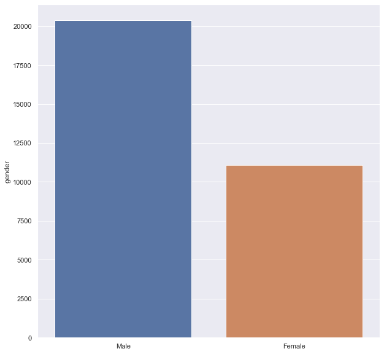

```python
import matplotlib.pyplot as plt
import seaborn as sns

sns.set(rc={'figure.figsize':(10,10)})


# plot barplot of gender
sns.barplot(x=df['gender'].value_counts().index, y=df['gender'].value_counts())
```

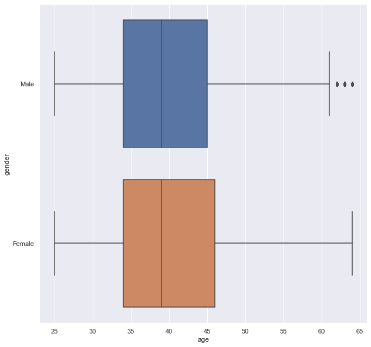

```python
# boxplot
sns.boxplot(x=df['age'], y=df['gender'])
```

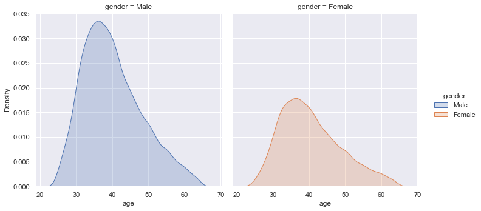

```python
sns.displot(df, x='age', col='gender', kind="kde", hue="gender", fill=True)
```

# Países

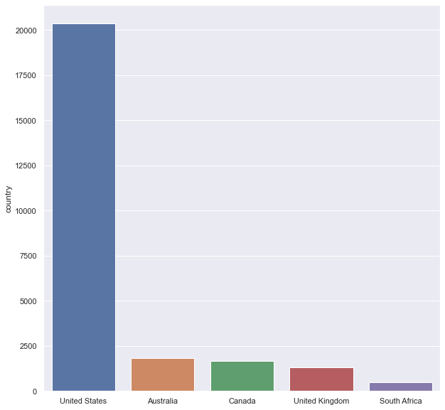

```python
# by country
sns.barplot(x=df['country'].value_counts().nlargest(5).index, y=df['country'].value_counts().nlargest(5))
```

# Altura y Peso

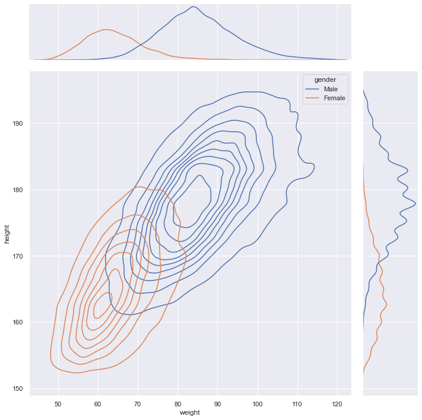

```python
sns.jointplot(
    data=df,
    x="weight",
    y="height",
    hue="gender",
    kind="kde",
    height=10
)
```

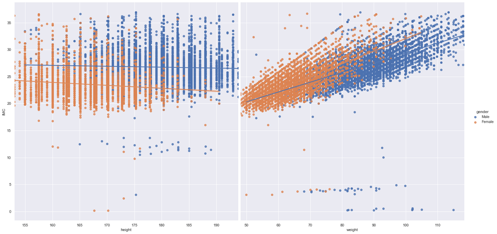

```python
sns.pairplot(df,
    x_vars=["height", "weight"],
    y_vars=["IMC"],
    hue="gender",
    kind="reg",
    height=10
    );
```

# Weightlifting Benchmarks Stats

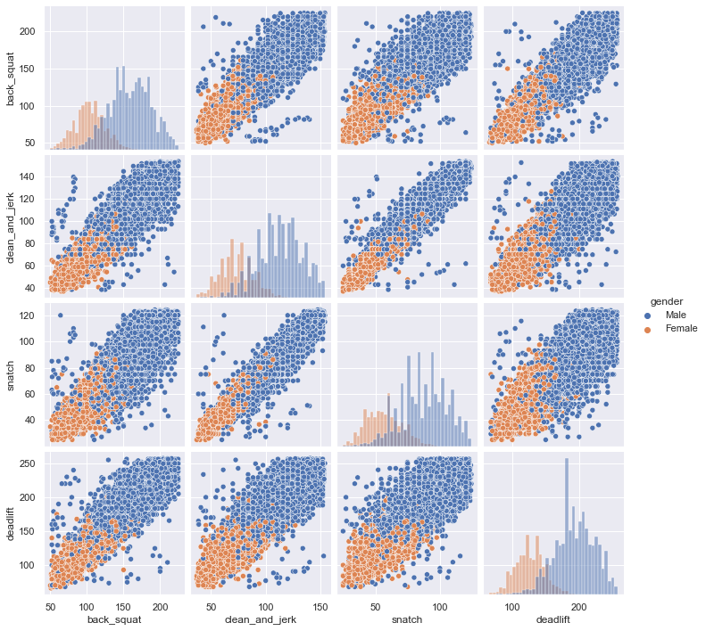

```python
sns.pairplot(df[['back_squat', 'clean_and_jerk', 'snatch', 'deadlift', 'gender']], hue='gender', diag_kind='hist')
```

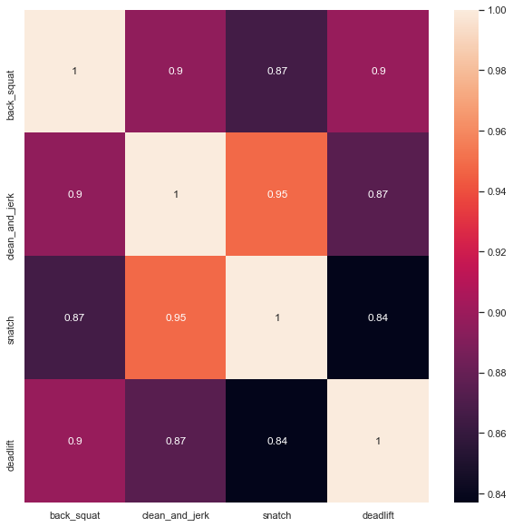

```python
# create heatmap with correlation between back_squat, clean_and_jerk, snatch and deadlift
weigthlifting_movements = ['back_squat', 'clean_and_jerk', 'snatch', 'deadlift']
corr = df[weigthlifting_movements].corr()
sns.heatmap(corr, annot=True)
```

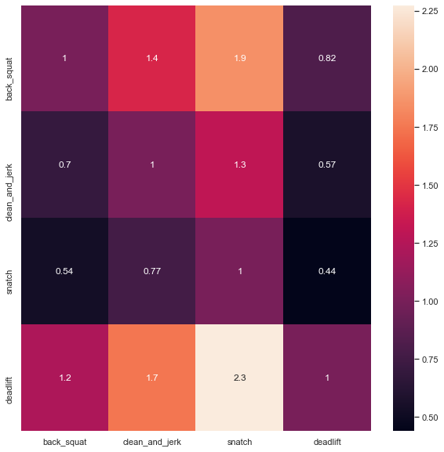

```python
def mean_matrix_relation(df, columns):
    """
    Returns a matrix with the relation between the mean of a column
    divided by the mean of the other columns.
    """
    mean_matrix = np.zeros((len(columns), len(columns)), dtype=np.float64)
    for i in range(0, len(columns)):
        for j in range(0, len(columns)):
            mean_matrix[i][j] = df[columns[i]].mean() / df[columns[j]].mean()
    return pd.DataFrame(data=mean_matrix, index=columns, columns=columns)

sns.heatmap(mean_matrix_relation(df, weigthlifting_movements), annot=True)
```

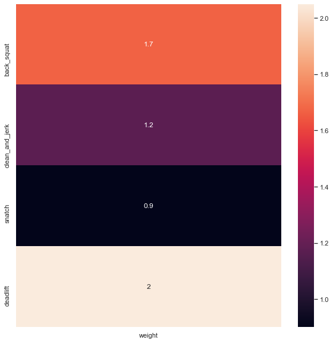

```python
def mean_vector_relation(df, columns, target):
    """
    Returns a vector with the relation between the mean of a column
    divided by the mean of the target.
    """
    mean_vector = np.zeros(len(columns), dtype=np.float64)
    for i in range(0, len(columns)):
        mean_vector[i] = df[columns[i]].mean() / df[target].mean()
    return pd.DataFrame(data=mean_vector, index=columns, columns=[target])

sns.heatmap(mean_vector_relation(df, weigthlifting_movements, 'weight'), annot=True)
```

# Reps Bechmarks

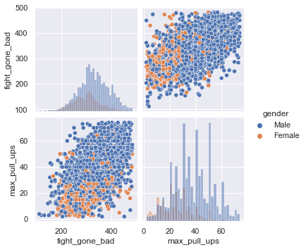

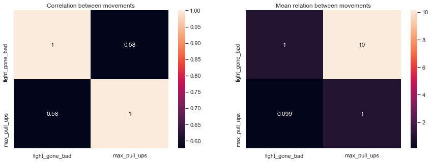

```python
reps_movements = ['fight_gone_bad', 'max_pull_ups']
sns.pairplot(df[(reps_movements + ["gender"])], hue='gender', diag_kind='hist')

fig, ax = plt.subplots(1,2, figsize=(15,5))
sns.heatmap(df[reps_movements].corr(), annot=True, ax=ax[0])
ax[0].set_title("Correlation between movements")
sns.heatmap(mean_matrix_relation(df, reps_movements), annot=True, ax=ax[1])
ax[1].set_title("Mean relation between movements")
```

# For time Bechmarks

```python
print(df['sprint_400m'].min(), df['sprint_400m'].max())
print(df['run_5k'].min(), df['run_5k'].max())

# la velocidad de paseo de 1 persona es de 4 km por hora, que equivale aprox a 1 metro por segundo (m/s)
# como máximo en hacer 400m tardará 400 segundos
df['sprint_400m'] = df['sprint_400m'].apply(lambda x: x if x > SPRINT_400M_MIN and x <= 400 else np.nan)
# la velocidad teórica que alcanza un humano corriendo es de 64 km/h. Usain Bolt, que puede correr a casi 42 km/h
```

```
50.0 3170.0
909.0 2570.0
```

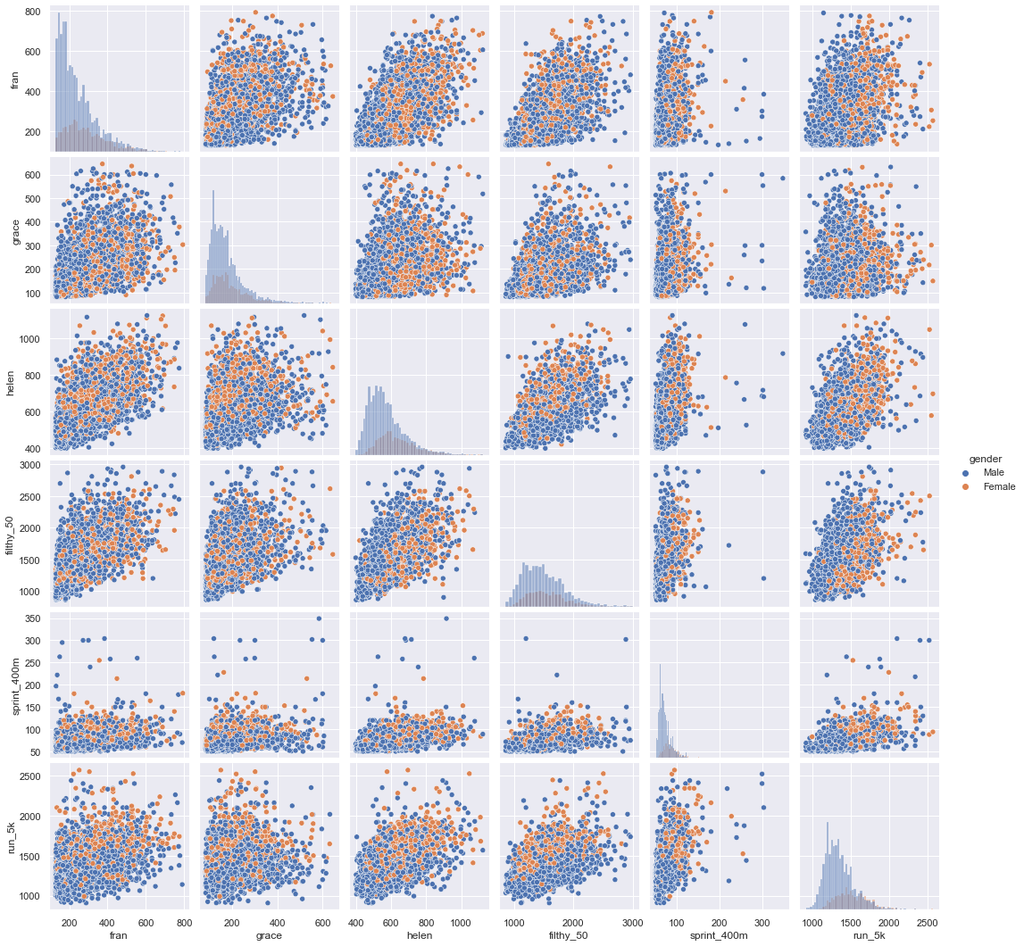

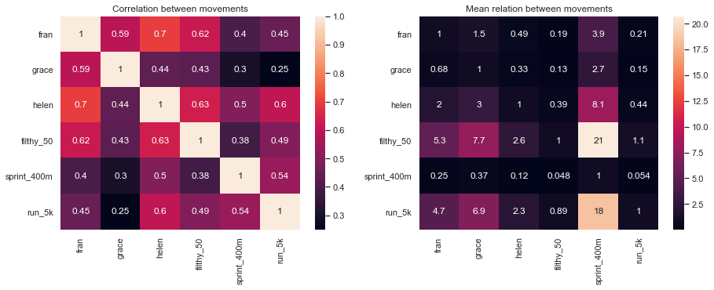

```python
for_time_movements = ['fran', 'grace', 'helen', 'filthy_50', 'sprint_400m', 'run_5k']

sns.pairplot(df[(for_time_movements + ['gender'])], hue='gender', diag_kind='hist')

fig, ax = plt.subplots(1,2, figsize=(15,5))
sns.heatmap(df[for_time_movements].corr(), annot=True, ax=ax[0])
ax[0].set_title("Correlation between movements")
sns.heatmap(mean_matrix_relation(df, for_time_movements), annot=True, ax=ax[1])
ax[1].set_title("Mean relation between movements")
```